# Data Visualization with R’s tidyverse

### two-variables

Various visualizations address the relation between two variables, whether discrete and/or continuous.

Especially for categorical data data could obscure other data. Deal with this using the position argument or with the `geom_jitter( )`. Avoid combining both `geom_point( )` and `geom_jitter( )` as it would draw points each time.

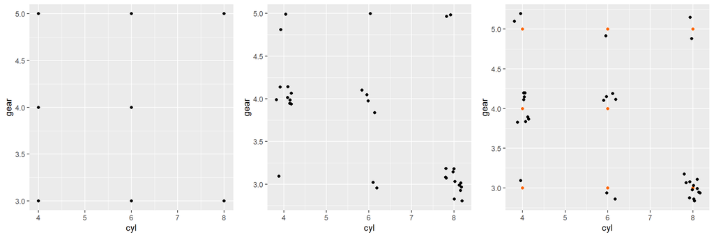

```r
p1 <- ggplot(data=mtcars,aes(cyl,gear)) + geom_point()
p2 <- ggplot(data=mtcars,aes(cyl,gear)) + geom_jitter(width=.2,height=.2)
p3 <- ggplot(data=mtcars,aes(cyl,gear)) + geom_point(color='#FF6600') + geom_jitter(width=.2,height=.2)
grid.arrange(p1,p2,p3,ncol=3)
```

The smooth function has been shown above, changing the confidence band into areas that capture that middle 50% (quantiles .25 and .75), and including a rug at the axes to capture the one dimensional distribution.

Instead of bullet indicators, the row names or any other set of labels can be used using the label argument (within the `aes( )` when related to data). A bit of jitter is added to avoid overlap.

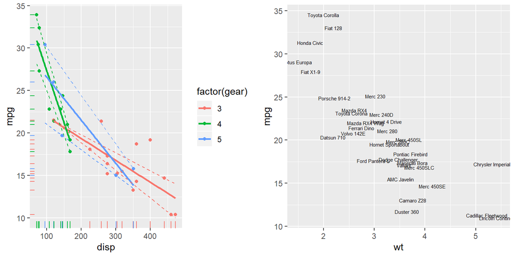

```r
p1 <- ggplot(data=mtcars, aes(y=mpg,x=disp,color=factor(gear))) + geom_point() + geom_smooth(method='lm',se=FALSE) + geom_rug() + geom_quantile(quantiles=c(.25,.75),linetype=2)
p2 <- ggplot(mtcars, aes(wt, mpg)) + geom_text(aes(label=(rownames(mtcars))),size=2,position=position_jitter(width = .2,height=3, seed=256))
grid.arrange(p1,p2,ncol=2)
```

```r
(tmp <- mtcars %>% group_by(gear,vs) %>% count())
```

```
| # A tibble: 6 x 3
| # Groups:   gear, vs [6]
|    gear    vs     n
|   <dbl> <dbl> <int>
| 1     3     0    12
| 2     3     1     3
| 3     4     0     2
| 4     4     1    10
| 5     5     0     4
| 6     5     1     1
```

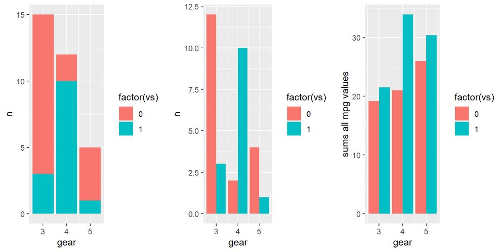

```r
p1 <- ggplot(tmp, aes(fill=factor(vs), y=n, x=gear)) + geom_bar(position="stack", stat="identity")
p2 <- ggplot(tmp, aes(fill=factor(vs), y=n, x=gear)) + geom_col(position="dodge")
p3 <- ggplot(mtcars, aes(fill=factor(vs), y=mpg, x=gear)) + geom_col(position="dodge") + labs(y='sums all mpg values')
grid.arrange(p1,p2,p3,ncol=3)
```

An interesting visualization for continuous data, possibly for different groups, is the boxplot.

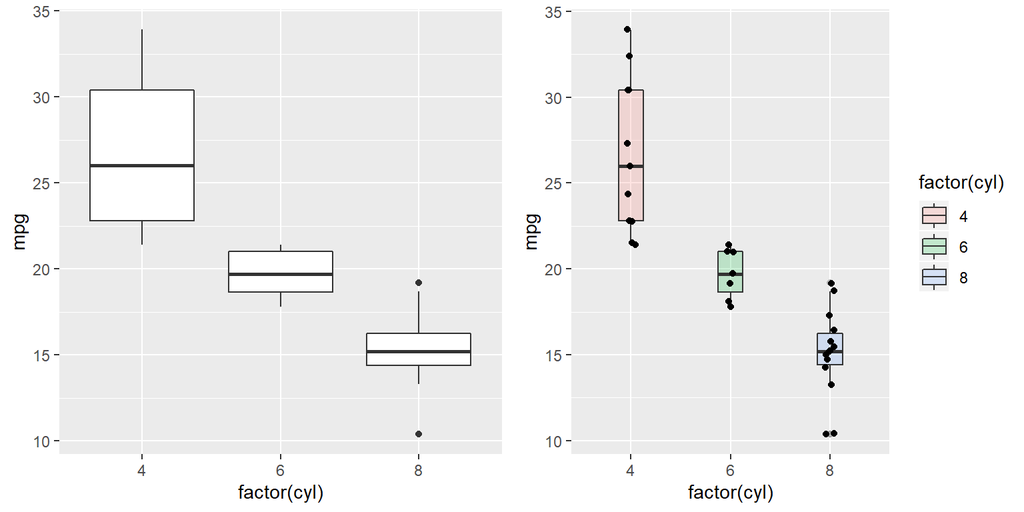

```r
p1 <- ggplot(data=mtcars,aes(y=mpg,x=factor(cyl))) + geom_boxplot()
p2 <- ggplot(data=mtcars,aes(y=mpg,x=factor(cyl))) +
    geom_boxplot(width=.25,alpha=.2,aes(fill=factor(cyl))) + geom_jitter(width=.05)
grid.arrange(p1,p2,ncol=2)
```

#### exercises on two variable visualizations

- use the `mpg` dataset
- make a scatterplot histogram for the continuously scaled `hwy` on `cty`, and color by `cyl`
- jitter the data, so it shows if data points obscure one-another
- make sure that `cyl` is categorical

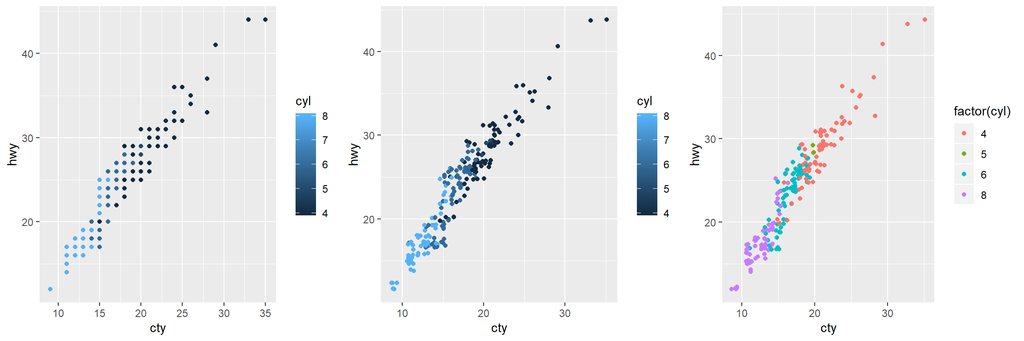

- add a conditional average with `geom_smooth( )`, use the `lm` method
- add a shape dependent on `class`, notice the restriction on the number of shapes
- switch the color and shapes around (color can have more than 6 if it is really necessary)
- make sure the symbols do not differ by color (all black), only shape, but keep the regression lines

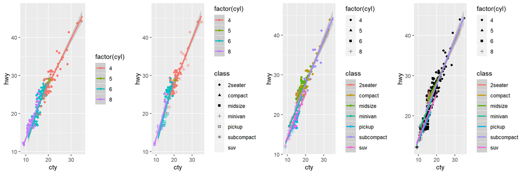

- show boxplots for the `hwy` for each `cyl`
- add the actual data points and make sure they do not obscure each other
- color the observations dependent on `class`

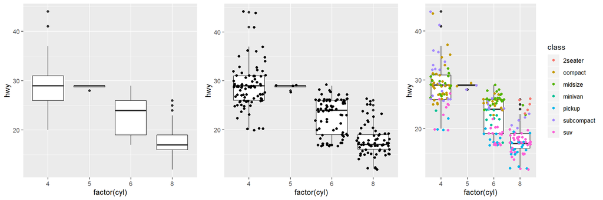

- make a bar chart that add all `hwy` values in each `class` group
- use a coloring of the bars to signal the relative contribution of all `cyl` categories

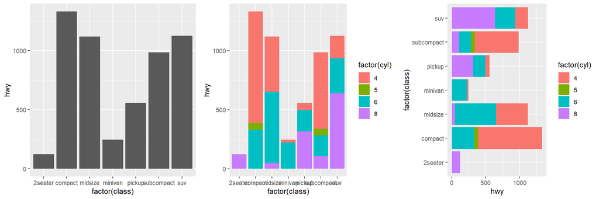

### intervals

Specialized functions facilitate visualization of errors.

When standard errors are obtained, along with fitted values, they are easily shown. Other intervals can be visualized this way too.

```r
(tmp <- tribble(~set,~fit,~se,1,3,.2,2,2,.3,3,2,.4))
```

```
| # A tibble: 3 x 3
|     set   fit    se
|   <dbl> <dbl> <dbl>
| 1     1     3   0.2
| 2     2     2   0.3
| 3     3     2   0.4
```

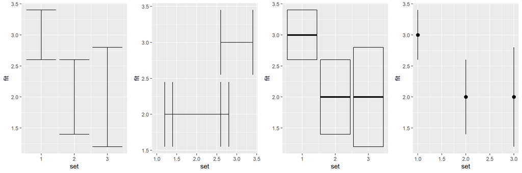

```r
px <- ggplot(data=tmp,aes(y=fit,x=set))
p1 <- px + geom_errorbar(aes(ymax=fit+2*se,ymin=fit-2*se))
p2 <- px + geom_errorbarh(aes(xmax=fit+2*se,xmin=fit-2*se))
p3 <- px + geom_crossbar(aes(ymax=fit+2*se,ymin=fit-2*se))
p4 <- px + geom_pointrange(aes(ymax=fit+2*se,ymin=fit-2*se))
grid.arrange(p1,p2,p3,p4,ncol=4)
```

### third variable implied

Frequencies and densities can be obtained for two variables.

With `geom_bin2d( )` the frequency of combinations is obtained, in this case for the factors cyl and gear. Because using bins also continuous variables can be used. The `geom_density2d( )` is also used with continuous variables, with contours depending on for example the gear levels.

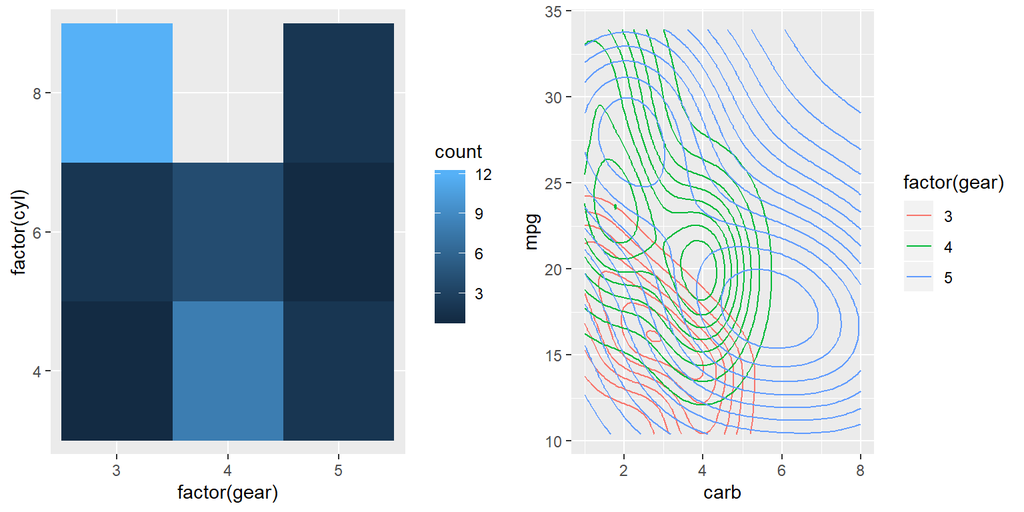

```r
p1 <- ggplot(data=mtcars,aes(y=factor(cyl),x=factor(gear))) + geom_bin2d()
p2 <- ggplot(data=mtcars,aes(y=mpg,x=carb)) + geom_density2d(aes(colour = factor(gear)))
grid.arrange(p1,p2,ncol=2)
```

### three variables

While typically a third variable is included using aesthetics, it can be done with the z dimension as well.

When a third dimension is linked to a combination of conditions, they are easily shown. For the example meaningless data are simulated, 100 observations of which the first 6 are shown.

```r
tmp <- expand.grid(set1=1:10,set2=1:10); set.seed(123); tmp$score <- runif(100,0,1)
head(tmp)
```

```
|   set1 set2     score
| 1    1    1 0.2875775
| 2    2    1 0.7883051
| 3    3    1 0.4089769
| 4    4    1 0.8830174
| 5    5    1 0.9404673
| 6    6    1 0.0455565
```

A heatmap is the most obvious use, to show for example correlations between many variables with colors instead of values. A small example is used instead. Notice that the argument for tile is a fill while for contour is is simply z.

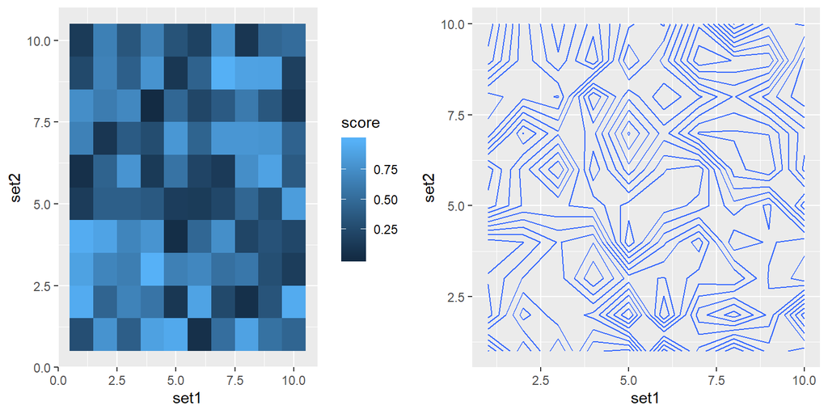

```r
p1 <- ggplot(data=tmp,aes(y=set2,x=set1)) + geom_tile(aes(fill=score))
p2 <- ggplot(data=tmp,aes(y=set2,x=set1)) + geom_contour(aes(z=score))
grid.arrange(p1,p2,ncol=2)
```

## Conclusion

ggplot2 is an excellent package, read more about it

Wickham, H. (2016). ggplot2: Elegant graphics for data analysis (Second edition). Springer.

or at

https://ggplot2-book.org/

to learn… just use it and keep on trying when you are stuck, check online, lots of help out there